# Analysis Pilot Study

Julian Sagebiel

1/22/2021

# Introduction

This file presents results from the pilot survey. It focuses on the choice experiment and is used to validate the design for the main study. The main study is about to be launched on 2nd February 2021.

Note the following:

split =1 – Environmental Treatment

split = 2 – Health treatment

split = 3 – Recipe Treatment

split = 4 – Baseline

# Preparation and base dataset

In the following R chunk, we read in all packages needed (including noting down their versions) and datasets, similar to the simulation

```r
dce_data <- ass_labels("pilotdata/tofu_main_swe_tofu.xlsx", seelab = FALSE)  #this function uses the labelled package to assign labels to the variables, helping to quickly grasp the content of the variables and values
```

```
## * `` -> ...2
## * `` -> ...3
## * `` -> ...4
```

```
## Number of variables in dataset:  17
##  Number of variables in label set: 17
```

```r
cov_data <- ass_labels("pilotdata/tofu_main_swe_covariates.xlsx" , seelab = FALSE)
```

```
## * `` -> ...2
## * `` -> ...3
## * `` -> ...4
```

```
## Number of variables in dataset:  70
##  Number of variables in label set: 70
```

We now prepare the data for the choice models and merge with the covariate datasets.

```r
  fulldata <-  dce_data%>%
    group_by(RID) %>%
    mutate(across(matches("._x3$") , ~ .x - 1 ) ) %>%
    mutate(a1_manuf_EU = a1_x1==2, a1_manuf_nonEU = a1_x1==3 , a2_manuf_EU = a2_x1==2, a2_manuf_nonEU = a2_x1==3 ,
           a1_cult_EU = a1_x2==2, a1_cult_nonEU = a1_x2==3 , a2_cult_EU = a2_x2==2, a2_cult_nonEU = a2_x2==3 ,
           across(matches("._x4$") ,  ~ dplyr::recode(  .x ,`1` = 15,`2` = 20  , `3` = 25 , `4` = 30 , `5` = 35 , `6` = 40 , `7` = 50 , `8` = 60 , .default =99999, .keep_value_labels = TRUE)) )   %>%
  left_join(cov_data, by = "RID")  %>%
  filter(STATUS==7) %>%
    as.data.frame()
```

# Descriptives

Here, we plot some relevant desciptive statistics. The first table shows the frequency of choices for each alternative. Then we create a new dataframe in long format, so that we can plot conditional choice probabilites, i.e. the probability to choose an alternative, given a certain attribute.

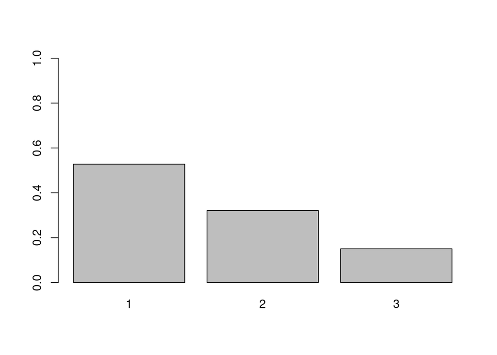

```r
  barplot(prop.table(table(fulldata$pref1)), ylim = c(0,1))
```

```r
long= dce_data %>% rename_with( ~ paste0(.,"_",str_extract(.,"._" )), starts_with("a") )%>%
  rename_with( ~ sub("^..." , "", .), starts_with("a")) %>%
  pivot_longer(matches("^x"), names_to = c(".value", "set"), names_sep = "_") %>% mutate(set=as.numeric(set), choice=pref1==set, across(starts_with("x"),  ~if_else(set==3,0,.) )  )
```

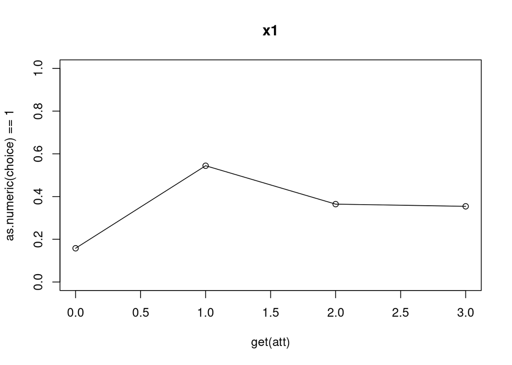

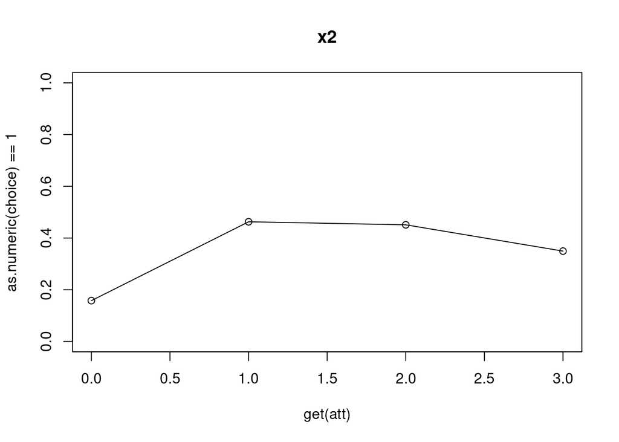

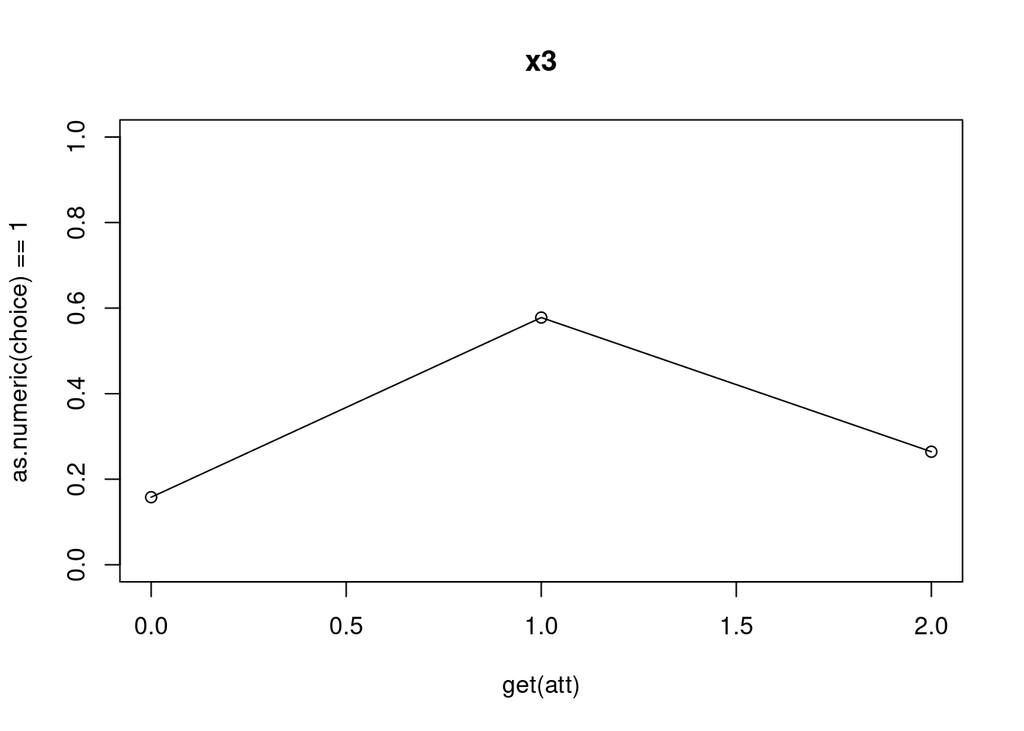

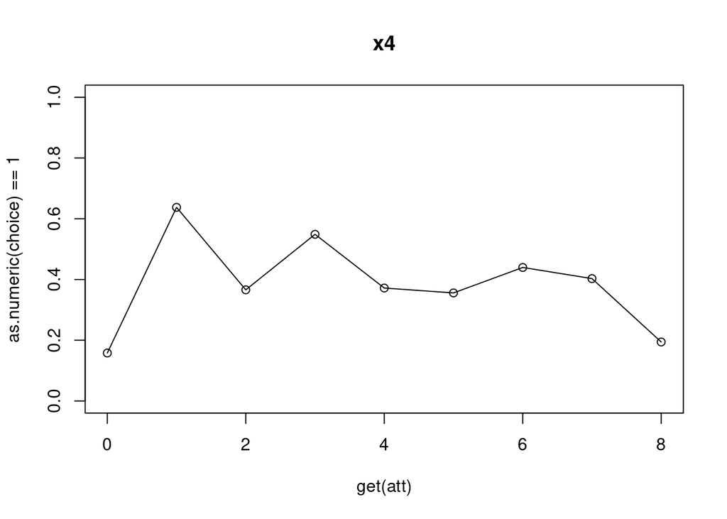

```r
for (att in c("x1","x2","x3","x4")) {



plot(aggregate(as.numeric(choice)==1 ~ get(att) , data=long , mean), type="o", main=att, ylim=0:1)

}
```

# Estimation of conditional logit model

Here, we estimate a conditional logit model with all respondents and calculate Willingness to pay. Then we do the same for each split sample. Before presenting the results, everything is stored in objects.

```r
database<-remove_all_labels(fulldata)  #labels need to be removed to estimate models in apollo
fullmodel <-mnl()

wtp_fullmodel <-wtp("bcost", names(fullmodel$estimate), model=fullmodel)
```

[output not shown]

```r
database_orig <-database


wtp_split=list()
model_split=list()


for (spl in unique(database_orig$split)) {


database <- database_orig %>%  filter(split==spl)

model_split[[spl]] <- mnl()

wtp_split[[spl]] <- wtp("bcost", names(model_split[[spl]]$estimate), model=model_split[[spl]])


}
```

```r
apollo_modelOutput(fullmodel, modelOutput_settings)
```

```
## Model run using Apollo for R, version 0.2.2 on Linux by julian
## www.ApolloChoiceModelling.com
##
## Model name                       : Pilot Data Tofu
## Model description                : Simple MNL model
## Model run at                     : 2021-01-25 18:41:47
## Estimation method                : bfgs
## Model diagnosis                  : successful convergence
## Number of individuals            : 101
## Number of rows in database       : 909
## Number of modelled outcomes      : 909
##
## Number of cores used             :  1
## Model without mixing
##
## LL(start)                        : -2330.611
## LL(0)                            : -998.6386
## LL(final)                        : -764.0306
## Rho-square (0)                   :  0.2349
## Adj.Rho-square (0)               :  0.2269
## AIC                              :  1544.06
## BIC                              :  1582.56
##
##
## Estimated parameters             :  8
## Time taken (hh:mm:ss)            :  00:00:2.53
##      pre-estimation              :  00:00:0.53
##      estimation                  :  00:00:0.41
##      post-estimation             :  00:00:1.59
## Iterations                       :  17
## Min abs eigenvalue of Hessian    :  7.644068
##
## Estimates:
##                Estimate        s.e.   t.rat.(0)  p(1-sided)    Rob.s.e.
## bascA           3.81812    0.248327      15.375       0.000    0.422386
## bascB           3.24978    0.233979      13.889       0.000    0.398268
## bcost          -0.03476    0.004601      -7.555   2.087e-14    0.005115
## bmanufEU       -0.65689    0.134717      -4.876   5.411e-07    0.130152
## bmanufnonEU    -0.94034    0.120359      -7.813   2.776e-15    0.146481
## bcultEU        -0.56744    0.135577      -4.185   1.424e-05    0.142090
## bcultnonEU     -0.72153    0.124972      -5.774   3.882e-09    0.143792
## bCONV          -1.04266    0.102661     -10.156       0.000    0.126848
##             Rob.t.rat.(0)  p(1-sided)
## bascA               9.039       0.000
## bascB               8.160   2.220e-16
## bcost              -6.796   5.368e-12
## bmanufEU           -5.047   2.243e-07
## bmanufnonEU        -6.420   6.836e-11
## bcultEU            -3.994   3.255e-05
## bcultnonEU         -5.018   2.612e-07
## bCONV              -8.220   1.110e-16
```

```r
cat("\n Results for full sample \n")
```

```
##
##  Results for full sample
```

```r
kable(wtp_fullmodel,digits = 2 , format = "simple" )
```

|  | wtp | robse | robt | pVal |
| --- | --- | --- | --- | --- |
| bascA | 109.84 | 12.53 | 8.76 | 0 |
| bascB | 93.49 | 11.31 | 8.27 | 0 |
| bmanufEU | -18.90 | 4.36 | -4.33 | 0 |
| bmanufnonEU | -27.05 | 5.82 | -4.65 | 0 |
| bcultEU | -16.32 | 4.48 | -3.64 | 0 |
| bcultnonEU | -20.76 | 4.72 | -4.40 | 0 |
| bCONV | -30.00 | 5.64 | -5.32 | 0 |

```r
cat("\n Results for the splits in the order split =1 -- Environmental Treatment

split = 2 -- Health treatment

split = 3 -- Recipe Treatment

split = 4 -- Baseline \n")
```

```
##
##  Results for the splits in the order split =1 -- Environmental Treatment
##
## split = 2 -- Health treatment
##
## split = 3 -- Recipe Treatment
##
## split = 4 -- Baseline
```

```r
kable(wtp_split,digits = 2 , format = "simple" )
```

|  | wtp | robse | robt | pVal |
| --- | --- | --- | --- | --- |
| bascA | 103.19 | 20.69 | 4.99 | 0.00 |
| bascB | 89.85 | 19.01 | 4.73 | 0.00 |
| bmanufEU | -16.59 | 6.65 | -2.49 | 0.01 |
| bmanufnonEU | -28.20 | 11.45 | -2.46 | 0.01 |
| bcultEU | -13.99 | 8.58 | -1.63 | 0.10 |
| bcultnonEU | -23.16 | 9.61 | -2.41 | 0.02 |
| bCONV | -34.32 | 9.92 | -3.46 | 0.00 |

|  | wtp | robse | robt | pVal |
| --- | --- | --- | --- | --- |
| bascA | 120.33 | 19.48 | 6.18 | 0.00 |
| bascB | 106.88 | 17.94 | 5.96 | 0.00 |
| bmanufEU | -23.37 | 7.92 | -2.95 | 0.00 |
| bmanufnonEU | -25.32 | 8.10 | -3.12 | 0.00 |
| bcultEU | -22.09 | 9.41 | -2.35 | 0.02 |
| bcultnonEU | -18.30 | 7.96 | -2.30 | 0.02 |
| bCONV | -27.07 | 9.03 | -3.00 | 0.00 |

|  | wtp | robse | robt | pVal |
| --- | --- | --- | --- | --- |
| bascA | 124.40 | 45.48 | 2.74 | 0.01 |
| bascB | 102.83 | 38.07 | 2.70 | 0.01 |
| bmanufEU | -22.34 | 11.94 | -1.87 | 0.06 |
| bmanufnonEU | -35.04 | 20.18 | -1.74 | 0.08 |
| bcultEU | -26.26 | 14.86 | -1.77 | 0.08 |
| bcultnonEU | -24.81 | 13.93 | -1.78 | 0.07 |
| bCONV | -40.51 | 19.97 | -2.03 | 0.04 |

|  | wtp | robse | robt | pVal |
| --- | --- | --- | --- | --- |
| bascA | 91.51 | 18.01 | 5.08 | 0.00 |
| bascB | 73.43 | 18.05 | 4.07 | 0.00 |
| bmanufEU | -14.40 | 7.95 | -1.81 | 0.07 |
| bmanufnonEU | -21.69 | 9.07 | -2.39 | 0.02 |
| bcultEU | -5.34 | 5.09 | -1.05 | 0.29 |
| bcultnonEU | -16.84 | 8.06 | -2.09 | 0.04 |
| bCONV | -18.92 | 8.64 | -2.19 | 0.03 |